# Series de tiempo - 1

Vásquez Guerra Carlos Fernando

2023-08-25

```r
library(tidyverse)
library(forecast)
library(lubridate)
library(patchwork)
```

Empezamos cargando nuestros datos, los cuales pueden ser obtenidos del siguiente [enlace](https://www.kaggle.com/datasets/souravprakashai/walmart-condensed-sales-data).

```r
walmart <- read_csv("walmart.csv")
walmart
```

| Store | Date | Weekly_Sales | Holiday_Flag | Temperature | Fuel_Price | CPI | Unemployment |
| --- | --- | --- | --- | --- | --- | --- | --- |
| 1 | 05-02-2010 | 1643690.9 | 0 | 42.31 | 2.572 | 211.0964 | 8.106 |
| 1 | 12-02-2010 | 1641957.4 | 1 | 38.51 | 2.548 | 211.2422 | 8.106 |
| 1 | 19-02-2010 | 1611968.2 | 0 | 39.93 | 2.514 | 211.2891 | 8.106 |
| 1 | 26-02-2010 | 1409727.6 | 0 | 46.63 | 2.561 | 211.3196 | 8.106 |
| 1 | 05-03-2010 | 1554806.7 | 0 | 46.50 | 2.625 | 211.3501 | 8.106 |
| 1 | 12-03-2010 | 1439541.6 | 0 | 57.79 | 2.667 | 211.3806 | 8.106 |
| 1 | 19-03-2010 | 1472515.8 | 0 | 54.58 | 2.720 | 211.2156 | 8.106 |
| 1 | 26-03-2010 | 1404429.9 | 0 | 51.45 | 2.732 | 211.0180 | 8.106 |
| 1 | 02-04-2010 | 1594968.3 | 0 | 62.27 | 2.719 | 210.8204 | 7.808 |
| 1 | 09-04-2010 | 1545418.5 | 0 | 65.86 | 2.770 | 210.6229 | 7.808 |

[output cut: 6425 more lines]

De manera inicial, realicemos una visualización de la serie de tiempo que podríamos obtener de las variables `Date` y `Weekly_Sales` y de algunos de los registros:

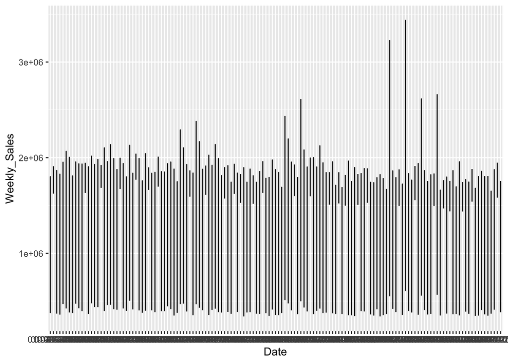

```r
walmart %>% head(400) %>% ggplot(aes(x = Date, y = Weekly_Sales)) + geom_line(stat = "identity")
```

Esta gráfica tiene un comportamiento extraño, ya que parece no tener un comportamiento continuo. El problema en este caso es que, originalmente, la variable `Date` es de tipo `String`. Modifiquemos el tipo de dato de esta:

```r
walmart <- walmart %>% mutate(Date = as.Date(Date, format = '%d-%m-%Y'))
```

Si graficamos la anterior muestra podemos ver que tenemos una mejor representación de la serie.

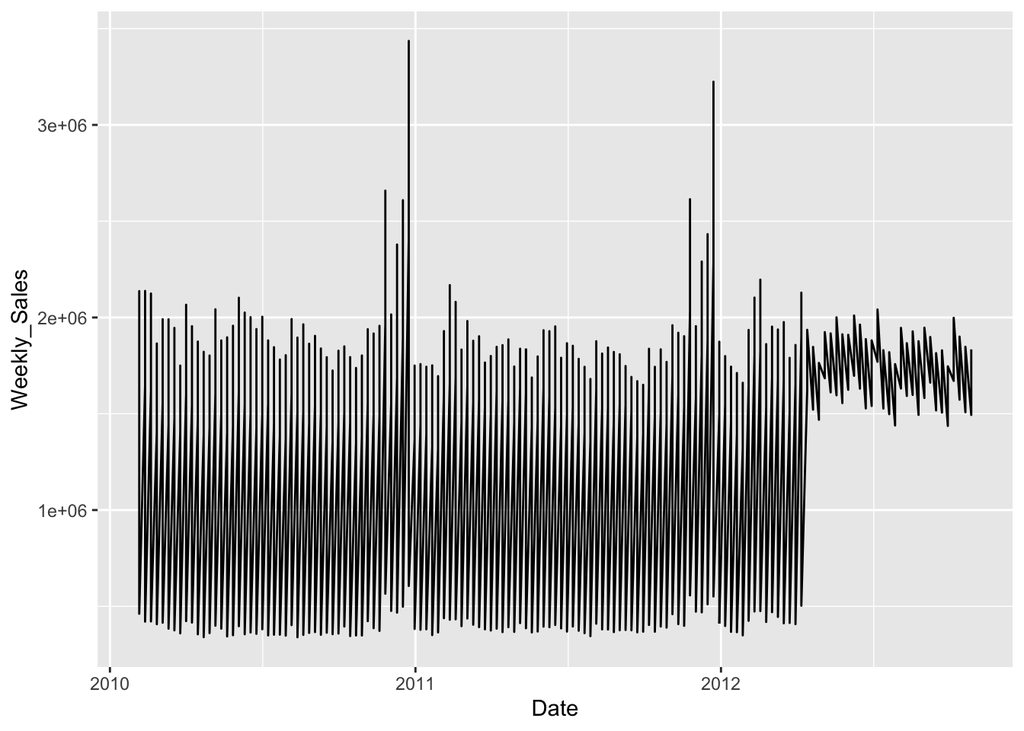

```r
walmart %>% head(400) %>% ggplot(aes(x = Date, y = Weekly_Sales)) + geom_line(stat = "identity")
```

Ahora, realicemos una serie de tiempo (un objeto `ts`):

```r
ts(walmart$Weekly_Sales, start = 2010)
```

```
## Time Series:
## Start = 2010
## End = 8444
## Frequency = 1
##    [1] 1643690.9 1641957.4 1611968.2 1409727.6 1554806.7 1439541.6 1472515.8
##    [8] 1404429.9 1594968.3 1545418.5 1466058.3 1391256.1 1425100.7 1603955.1
##   [15] 1494251.5 1399662.1 1432069.9 1615524.7 1542561.1 1503284.1 1422711.6
##   [22] 1492418.1 1546074.2 1448938.9 1385065.2 1371986.6 1605491.8 1508237.8
##   [29] 1513080.5 1449142.9 1540163.5 1507460.7 1430378.7 1351791.0 1453329.5
##   [36] 1508239.9 1459409.1 1345454.0 1384209.2 1551659.3 1494479.5 1483784.2
##   [43] 1955624.1 1548033.8 1682614.3 1891034.9 2387950.2 1367320.0 1444732.3
##   [50] 1391014.0 1327405.4 1316899.3 1606629.6 1649614.9 1686842.8 1456800.3
##   [57] 1636263.4 1553191.6 1576818.1 1541102.4 1495064.8 1614259.4 1559889.0
##   [64] 1564819.8 1455090.7 1629391.3 1604775.6 1428218.3 1466046.7 1635078.4
##   [71] 1588948.3 1532114.9 1438830.1 1488538.1 1534849.6 1455120.0 1396926.8
```

[output cut: 909 more lines]

Y como vemos, nos falta declarar más detalle en la construcción de la serie.

```r
print(min(walmart$Date))
```

```
## [1] "2010-02-05"
```

```r
print(max(walmart$Date))
```

```
## [1] "2012-10-26"
```

Sabemos la fecha más antigua y la más cercana registrada. Tomemos un año y veamos cuantos registros tenemos en esta unidad de tiempo

```r
walmart  %>% filter(Date < as.Date("2012-01-01") & Date > as.Date("2010-12-31")) %>% group_by(Store) %>% summarise(n())
```

| Store | n() |
| --- | --- |
| 1 | 52 |
| 2 | 52 |
| 3 | 52 |
| 4 | 52 |
| 5 | 52 |
| 6 | 52 |
| 7 | 52 |
| 8 | 52 |
| 9 | 52 |
| 10 | 52 |

[output cut: 35 more lines]

Véase que utilizamos la variable `Store` para agrupar, ya que no todos los registros corresponden a una sola tienda. En este punto, podemos deducir que tenemos la información recabada en cada semana.

```r
ts(walmart$Weekly_Sales, start = c(2010), frequency = 52)
```

```
## Time Series:
## Start = c(2010, 1)
## End = c(2133, 39)
## Frequency = 52
##    [1] 1643690.9 1641957.4 1611968.2 1409727.6 1554806.7 1439541.6 1472515.8
##    [8] 1404429.9 1594968.3 1545418.5 1466058.3 1391256.1 1425100.7 1603955.1
##   [15] 1494251.5 1399662.1 1432069.9 1615524.7 1542561.1 1503284.1 1422711.6
##   [22] 1492418.1 1546074.2 1448938.9 1385065.2 1371986.6 1605491.8 1508237.8
##   [29] 1513080.5 1449142.9 1540163.5 1507460.7 1430378.7 1351791.0 1453329.5
##   [36] 1508239.9 1459409.1 1345454.0 1384209.2 1551659.3 1494479.5 1483784.2
##   [43] 1955624.1 1548033.8 1682614.3 1891034.9 2387950.2 1367320.0 1444732.3
##   [50] 1391014.0 1327405.4 1316899.3 1606629.6 1649614.9 1686842.8 1456800.3
##   [57] 1636263.4 1553191.6 1576818.1 1541102.4 1495064.8 1614259.4 1559889.0
##   [64] 1564819.8 1455090.7 1629391.3 1604775.6 1428218.3 1466046.7 1635078.4
##   [71] 1588948.3 1532114.9 1438830.1 1488538.1 1534849.6 1455120.0 1396926.8
```

[output cut: 909 more lines]

Reducimos considerablemente el rango de fechas en la serie, aunque aún no es lo deseado. En este momento no hemos considerado que tenemos registros de cada tienda en el conjunto de datos, por lo que tomemos solo una (la primera, por ejemplo) para reducir nuestos datos

```r
first_store <- walmart %>% filter(Store == 1)
ts(first_store$Weekly_Sales, start = 2010, frequency = 52)
```

```
## Time Series:
## Start = c(2010, 1)
## End = c(2012, 39)
## Frequency = 52
##   [1] 1643691 1641957 1611968 1409728 1554807 1439542 1472516 1404430 1594968
##  [10] 1545419 1466058 1391256 1425101 1603955 1494252 1399662 1432070 1615525
##  [19] 1542561 1503284 1422712 1492418 1546074 1448939 1385065 1371987 1605492
##  [28] 1508238 1513080 1449143 1540164 1507461 1430379 1351791 1453330 1508240
##  [37] 1459409 1345454 1384209 1551659 1494479 1483784 1955624 1548034 1682614
##  [46] 1891035 2387950 1367320 1444732 1391014 1327405 1316899 1606630 1649615
##  [55] 1686843 1456800 1636263 1553192 1576818 1541102 1495065 1614259 1559889
##  [64] 1564820 1455091 1629391 1604776 1428218 1466047 1635078 1588948 1532115
##  [73] 1438830 1488538 1534850 1455120 1396927 1352220 1624384 1525147 1530761
##  [82] 1464693 1550229 1540471 1514260 1380020 1394562 1630990 1493526 1502563
##  [91] 1445249 1697230 1594939 1539484 2033321 1584084 1799682 1881177 2270189
## [100] 1497463 1550370 1459601 1394394 1319326 1636340 1802477 1819870 1539388
## [109] 1688421 1675431 1677473 1511068 1649605 1899677 1621032 1521578 1468928
## [118] 1684520 1611096 1595902 1555445 1624478 1697231 1630607 1527846 1540421
## [127] 1769854 1527014 1497955 1439124 1631136 1592410 1597868 1494122 1582083
## [136] 1661767 1517429 1506126 1437059 1670786 1573073 1508069 1493660
```

Perfecto, ya tenemos un rango más creíble, aunque no comenzamos en la primera semana del año 2010 en el conjunto de datos, si no en la semana que correponde al 5 de febrero del 2010

```r
first_store
```

| Store | Date | Weekly_Sales | Holiday_Flag | Temperature | Fuel_Price | CPI | Unemployment |
| --- | --- | --- | --- | --- | --- | --- | --- |
| 1 | 2010-02-05 | 1643691 | 0 | 42.31 | 2.572 | 211.0964 | 8.106 |
| 1 | 2010-02-12 | 1641957 | 1 | 38.51 | 2.548 | 211.2422 | 8.106 |
| 1 | 2010-02-19 | 1611968 | 0 | 39.93 | 2.514 | 211.2891 | 8.106 |
| 1 | 2010-02-26 | 1409728 | 0 | 46.63 | 2.561 | 211.3196 | 8.106 |
| 1 | 2010-03-05 | 1554807 | 0 | 46.50 | 2.625 | 211.3501 | 8.106 |
| 1 | 2010-03-12 | 1439542 | 0 | 57.79 | 2.667 | 211.3806 | 8.106 |
| 1 | 2010-03-19 | 1472516 | 0 | 54.58 | 2.720 | 211.2156 | 8.106 |
| 1 | 2010-03-26 | 1404430 | 0 | 51.45 | 2.732 | 211.0180 | 8.106 |
| 1 | 2010-04-02 | 1594968 | 0 | 62.27 | 2.719 | 210.8204 | 7.808 |
| 1 | 2010-04-09 | 1545419 | 0 | 65.86 | 2.770 | 210.6229 | 7.808 |

[output cut: 133 more lines]

Vamos a considerar lo anterior para tener un objeto de serie de tiempo más adecuado.

```r
first_week_Store_1 <- first_store$Date %>% min() %>% week()
last_week_Store_1 <- first_store$Date %>% max() %>% week()

print(paste0("Se tienen los datos desde la semana ", first_week_Store_1,
      " del 2010 hasta la semana ", last_week_Store_1, " del 2012"))
```

```
## [1] "Se tienen los datos desde la semana 6 del 2010 hasta la semana 43 del 2012"
```

```r
(serie_first_store <- ts(first_store$Weekly_Sales, start = c(2010, first_week_Store_1), frequency = 52))
```

```
## Time Series:
## Start = c(2010, 6)
## End = c(2012, 44)
## Frequency = 52
##   [1] 1643691 1641957 1611968 1409728 1554807 1439542 1472516 1404430 1594968
##  [10] 1545419 1466058 1391256 1425101 1603955 1494252 1399662 1432070 1615525
##  [19] 1542561 1503284 1422712 1492418 1546074 1448939 1385065 1371987 1605492
##  [28] 1508238 1513080 1449143 1540164 1507461 1430379 1351791 1453330 1508240
##  [37] 1459409 1345454 1384209 1551659 1494479 1483784 1955624 1548034 1682614
##  [46] 1891035 2387950 1367320 1444732 1391014 1327405 1316899 1606630 1649615
##  [55] 1686843 1456800 1636263 1553192 1576818 1541102 1495065 1614259 1559889
##  [64] 1564820 1455091 1629391 1604776 1428218 1466047 1635078 1588948 1532115
##  [73] 1438830 1488538 1534850 1455120 1396927 1352220 1624384 1525147 1530761
##  [82] 1464693 1550229 1540471 1514260 1380020 1394562 1630990 1493526 1502563
##  [91] 1445249 1697230 1594939 1539484 2033321 1584084 1799682 1881177 2270189
## [100] 1497463 1550370 1459601 1394394 1319326 1636340 1802477 1819870 1539388
## [109] 1688421 1675431 1677473 1511068 1649605 1899677 1621032 1521578 1468928
## [118] 1684520 1611096 1595902 1555445 1624478 1697231 1630607 1527846 1540421
## [127] 1769854 1527014 1497955 1439124 1631136 1592410 1597868 1494122 1582083
## [136] 1661767 1517429 1506126 1437059 1670786 1573073 1508069 1493660
```

Ya que tenemos una mejor abstracción, volvamos a visualizar la serie:

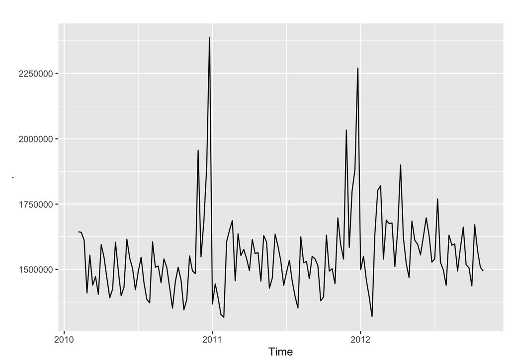

```r
serie_first_store %>% forecast::autoplot()
```

Podemos ver una tendencia a la alza y diferentes patrones de estacionalidad en la serie, lo ccual se cconfirma al realizar una descomposición aditiva de la serie:

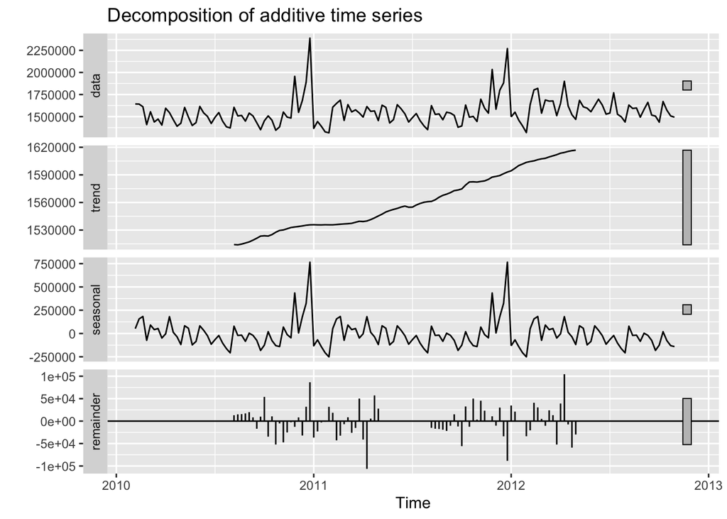

```r
serie_first_store %>% decompose() %>% forecast::autoplot()
```

De manera rápida y sin centrarnos en el diseño de las gráficas, podemos ver que ese efecto de estacionalidad es visible en las gráficas de autocorrelación y autocorrelación pacial

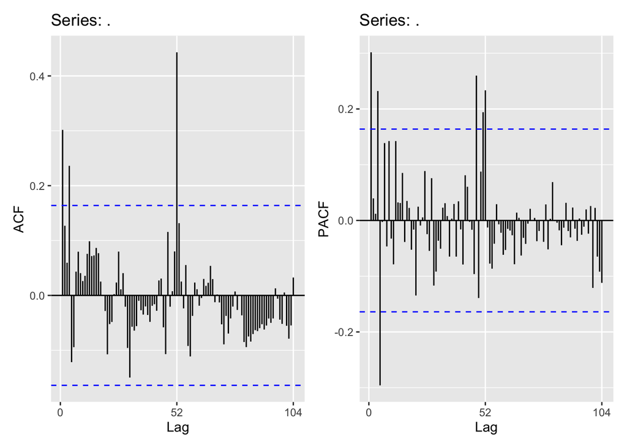

```r
(serie_first_store %>% ggAcf()) + (serie_first_store %>% ggPacf())
```